# FIFA DreamTeam

Tlotliso Jonas & Matthew Roberts

04/07/2020

### Project Description

The aim of the project was to a use data driven approach to build a budget constrained, winning soccer team using the relationship between player statistics and their value. Three teams will be created, the first one with a limited budget of 500 millions, the second one with the budget limit of 700 millions and the third unconstrained team. Additionally, we have created our own team layout and thus have selected our players so to fit this layout and have players on the bench. The three teams will then be compared on their overall ratings and total value of the team.

We have first cleaned the data set, then examined the relationship and distributions between variables. Thereafter we have analyzed various regression methods as well as breaking down and understanding the player characteristics We have then used the regression model and characteristics we deemed most suitable to value the players. Finally we have created the constrained and unconstrained teams.

### Data Cleaning

We first import the data and then analyze different variables.

```r
  fifa<-read.csv('data.csv')
```

We now examine the structure of the data

```r
summary(fifa)
```

```
##       ï..              ID             Name                Age
##  Min.   :    0   Min.   :    16   Length:18207       Min.   :16.00
##  1st Qu.: 4552   1st Qu.:200316   Class :character   1st Qu.:21.00
##  Median : 9103   Median :221759   Mode  :character   Median :25.00
##  Mean   : 9103   Mean   :214298                      Mean   :25.12
##  3rd Qu.:13654   3rd Qu.:236530                      3rd Qu.:28.00
##  Max.   :18206   Max.   :246620                      Max.   :45.00
##
##     Photo           Nationality            Flag              Overall
##  Length:18207       Length:18207       Length:18207       Min.   :46.00
##  Class :character   Class :character   Class :character   1st Qu.:62.00
##  Mode  :character   Mode  :character   Mode  :character   Median :66.00
##                                                           Mean   :66.24
##                                                           3rd Qu.:71.00
##                                                           Max.   :94.00
##
##    Potential         Club            Club.Logo            Value
##  Min.   :48.00   Length:18207       Length:18207       Length:18207
##  1st Qu.:67.00   Class :character   Class :character   Class :character
##  Median :71.00   Mode  :character   Mode  :character   Mode  :character
##  Mean   :71.31
##  3rd Qu.:75.00
##  Max.   :95.00
##
##      Wage              Special     Preferred.Foot     International.Reputation
##  Length:18207       Min.   : 731   Length:18207       Min.   :1.000
##  Class :character   1st Qu.:1457   Class :character   1st Qu.:1.000
##  Mode  :character   Median :1635   Mode  :character   Median :1.000
##                     Mean   :1598                      Mean   :1.113
##                     3rd Qu.:1787                      3rd Qu.:1.000
##                     Max.   :2346                      Max.   :5.000
##                                                       NA's   :48
##    Weak.Foot      Skill.Moves     Work.Rate          Body.Type
##  Min.   :1.000   Min.   :1.000   Length:18207       Length:18207
##  1st Qu.:3.000   1st Qu.:2.000   Class :character   Class :character
##  Median :3.000   Median :2.000   Mode  :character   Mode  :character
##  Mean   :2.947   Mean   :2.361
##  3rd Qu.:3.000   3rd Qu.:3.000
##  Max.   :5.000   Max.   :5.000
##  NA's   :48      NA's   :48
```

[output cut: 121 more lines]

```
##  Min.   : 1.00   Min.   : 1.00   Min.   : 1.00   Min.   : 1.00
##  1st Qu.: 8.00   1st Qu.: 8.00   1st Qu.: 8.00   1st Qu.: 8.00
##  Median :11.00   Median :11.00   Median :11.00   Median :11.00
##  Mean   :16.62   Mean   :16.39   Mean   :16.23   Mean   :16.39
##  3rd Qu.:14.00   3rd Qu.:14.00   3rd Qu.:14.00   3rd Qu.:14.00
##  Max.   :90.00   Max.   :92.00   Max.   :91.00   Max.   :90.00
##  NA's   :48      NA's   :48      NA's   :48      NA's   :48
##    GKReflexes    Release.Clause
##  Min.   : 1.00   Length:18207
##  1st Qu.: 8.00   Class :character
##  Median :11.00   Mode  :character
##  Mean   :16.71
##  3rd Qu.:14.00
##  Max.   :94.00
##  NA's   :48
```

From the summary output above it can be noted that this is a big data set, we have 18207 rows and 89 columns. Most of these variables such as Nationality, Flag and Club logo will not be used in the analysis and will therefore be removed to reduce the size of the data set which will improve efficiency of the analysis later.

```r
#delete the first col
fifa<-fifa[-c(1)]
#list of columns to be deleted
del_cols<-c('Flag','International.Reputation','Loaned.From','Photo','Club.Logo','Body.Type','Jersey.Number','Contract.Valid.Until','Release.Clause','Nationality','Real.Face','Joined','Weak.Foot','Work.Rate')
#delete these columns
data<-select(fifa,-all_of(del_cols))
attach(data)
```

We can now have a peek at the remaining data

```r
head(data)
```

```
##       ID              Name Age Overall Potential                Club     Value
## 1 158023          L. Messi  31      94        94        FC Barcelona â‚¬110.5M
## 2  20801 Cristiano Ronaldo  33      94        94            Juventus    â‚¬77M
## 3 190871         Neymar Jr  26      92        93 Paris Saint-Germain â‚¬118.5M
## 4 193080            De Gea  27      91        93   Manchester United    â‚¬72M
## 5 192985      K. De Bruyne  27      91        92     Manchester City   â‚¬102M
## 6 183277         E. Hazard  27      91        91             Chelsea    â‚¬93M
##      Wage Special Preferred.Foot Skill.Moves Position Height Weight   LS   ST
## 1 â‚¬565K    2202           Left           4       RF    5'7 159lbs 88+2 88+2
## 2 â‚¬405K    2228          Right           5       ST    6'2 183lbs 91+3 91+3
## 3 â‚¬290K    2143          Right           5       LW    5'9 150lbs 84+3 84+3
## 4 â‚¬260K    1471          Right           1       GK    6'4 168lbs
## 5 â‚¬355K    2281          Right           4      RCM   5'11 154lbs 82+3 82+3
## 6 â‚¬340K    2142          Right           4       LF    5'8 163lbs 83+3 83+3
##     RS   LW   LF   CF   RF   RW  LAM  CAM  RAM   LM  LCM   CM  RCM   RM  LWB
```

[output cut: 48 more lines]

It can be noted that the Value and Wage column have a strange format and will not be useful in numeric operations later if they have that format. In the code below we write a function and use it to clean up these two columns.

```r
#A function for cleaning wage and value columns
fix_value<-function(value){
  clean_value<-str_remove(value,"â‚¬")
  if (str_detect(clean_value,"M"))
  {
     clean_value<-as.numeric(str_remove(clean_value,"M"))*1e6
  }
  else if (str_detect(clean_value,"K"))
  {
     clean_value<-as.numeric(str_remove(clean_value,"K"))*1e3
  }
  return (clean_value)
}

#Clean the wage and value columns
data$Value<-as.numeric(lapply(data$Value,fix_value))
data$Wage<-as.numeric(lapply(data$Wage,fix_value))
head(select(fifa,all_of(c('Name','Value','Wage'))))
```

```
##                Name     Value    Wage
## 1          L. Messi â‚¬110.5M â‚¬565K
## 2 Cristiano Ronaldo    â‚¬77M â‚¬405K
## 3         Neymar Jr â‚¬118.5M â‚¬290K
## 4            De Gea    â‚¬72M â‚¬260K
## 5      K. De Bruyne   â‚¬102M â‚¬355K
## 6         E. Hazard    â‚¬93M â‚¬340K
```

It can also be noted above in the summary results that some of the columns of player attributes contains missing values and in the code below we replace these missing values with the average values of those columns.

```r
#replace missing values with average values
data$Crossing<-replace_na(data$Crossing,mean(Crossing[!is.na(Crossing)]))
data$Finishing<-replace_na(data$Finishing,mean(Finishing[!is.na(Finishing)]))
data$HeadingAccuracy<-replace_na(HeadingAccuracy,mean(HeadingAccuracy[!is.na(HeadingAccuracy)]))
data$ShortPassing<-replace_na(ShortPassing,mean(ShortPassing[!is.na(ShortPassing)]))
data$Volleys<-replace_na(Volleys,mean(Volleys[!is.na(Volleys)]))
data$Dribbling<-replace_na(Dribbling,mean(Dribbling[!is.na(Dribbling)]))
data$Curve<-replace_na(Curve,mean(Curve[!is.na(Curve)]))
data$FKAccuracy<-replace_na(FKAccuracy,mean(FKAccuracy[!is.na(FKAccuracy)]))
data$LongPassing<-replace_na(LongPassing,mean(LongPassing[!is.na(LongPassing)]))
data$BallControl<-replace_na(BallControl,mean(BallControl[!is.na(BallControl)]))
data$Acceleration<-replace_na(Acceleration,mean(Acceleration[!is.na(Acceleration)]))
data$SprintSpeed<-replace_na(SprintSpeed,mean(SprintSpeed[!is.na(SprintSpeed)]))
data$Agility<-replace_na(Agility,mean(Agility[!is.na(Agility)]))
data$Reactions<-replace_na(Reactions,mean(Reactions[!is.na(Reactions)]))
data$Balance<-replace_na(Balance,mean(Balance[!is.na(Balance)]))
data$ShotPower<-replace_na(ShotPower,mean(ShotPower[!is.na(ShotPower)]))
data$Jumping<-replace_na(Jumping,mean(Jumping[!is.na(Jumping)]))
data$Stamina<-replace_na(Stamina,mean(Stamina[!is.na(Stamina)]))
data$Strength<-replace_na(Strength,mean(Strength[!is.na(Strength)]))
data$LongShots<-replace_na(LongShots,mean(LongShots[!is.na(LongShots)]))
data$Aggression<-replace_na(Aggression,mean(Aggression[!is.na(Aggression)]))
data$Interceptions<-replace_na(Interceptions,mean(Interceptions[!is.na(Interceptions)]))
data$Positioning<-replace_na(Positioning,mean(Positioning[!is.na(Positioning)]))
data$Vision<-replace_na(data$Vision,mean(Vision[!is.na(Vision)]))
data$Penalties<-replace_na(Penalties,mean(Penalties[!is.na(Penalties)]))
data$Composure<-replace_na(Composure,mean(Composure[!is.na(Composure)]))
data$Marking<-replace_na(Marking,mean(Marking[!is.na(Marking)]))
data$StandingTackle<-replace_na(data$StandingTackle,mean(Vision[!is.na(StandingTackle)]))
data$SlidingTackle<-replace_na(SlidingTackle,mean(SlidingTackle[!is.na(SlidingTackle)]))
data$GKDiving<-replace_na(GKDiving,mean(GKDiving[!is.na(GKDiving)]))
data$GKHandling<-replace_na(GKHandling,mean(GKHandling[!is.na(GKHandling)]))
data$GKKicking<-replace_na(GKKicking,mean(GKKicking[!is.na(GKKicking)]))
data$GKPositioning<-replace_na(GKPositioning,mean(GKPositioning[!is.na(GKPositioning)]))
data$GKReflexes<-replace_na(GKReflexes,mean(GKReflexes[!is.na(GKReflexes)]))
data$Skill.Moves<-replace_na(Skill.Moves,mean(Skill.Moves[!is.na(Skill.Moves)]))
attach(data)
```

### Data Understanding

We analyze different aspects of the data by plotting distributions of variables:

#### Preferred Foot

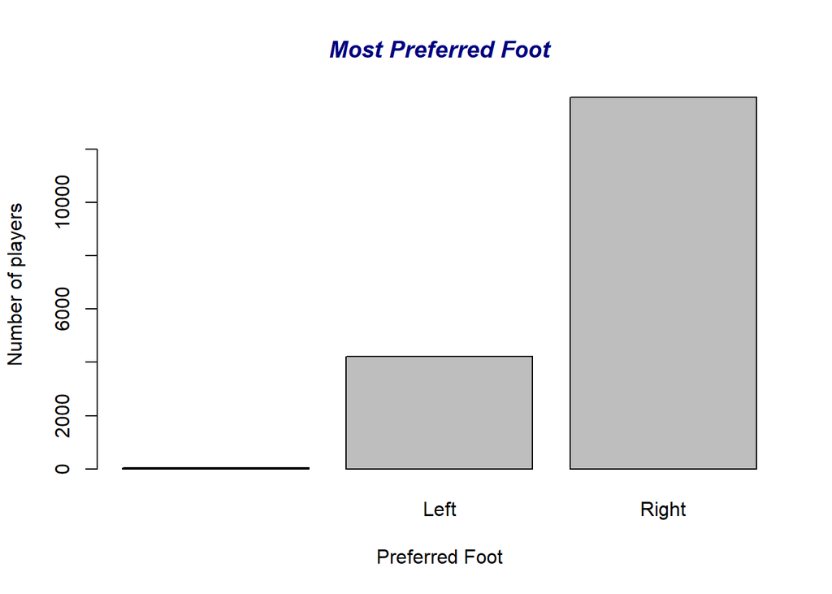

From the plot above it can be seen that most fifa players are right footed and there are also very few players who do not have foot preference.

#### Age Distribution

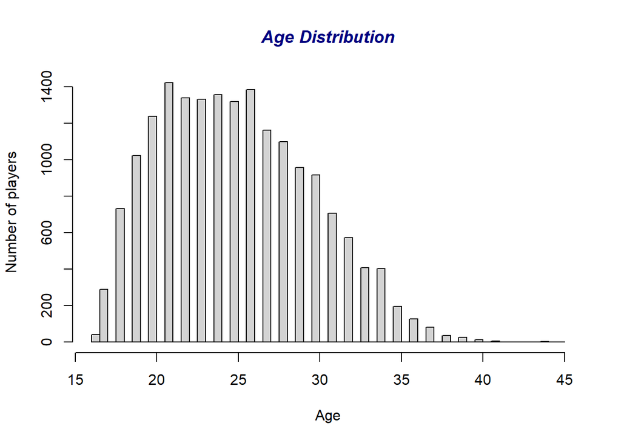

From the age distribution above it can be observed that most fifa players are between 20 to 25 years of age and it can also be noted that the youngest player is 16 years old while the oldest is 45 years old. This may form an important aspect of the team selection so to strengthen the longevity of the team.

#### Positions Distributions

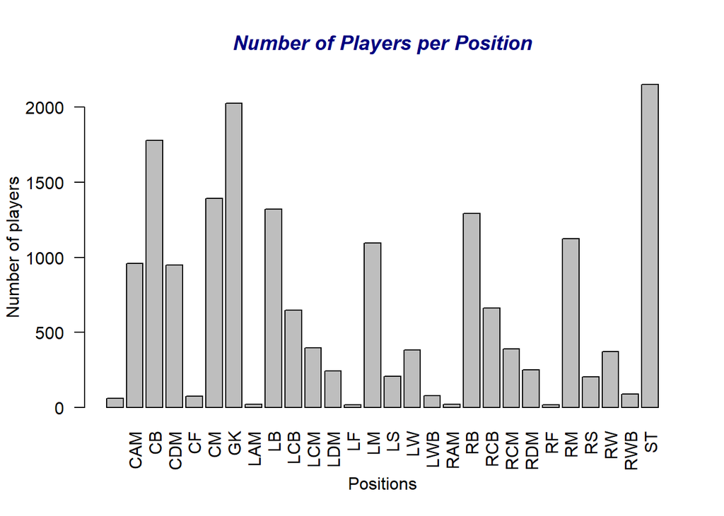

In this plot we observe the number of players per position and it can be noted that some positions such as goalkeeping and striker have a lot of players while other positions such as left forward and right forward are being played by very few players. This may result in a better estimation of value where the sample size is larger.

#### Wage Distribution

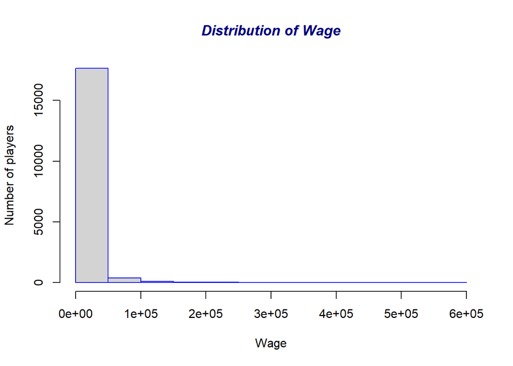

#### Value Distribution

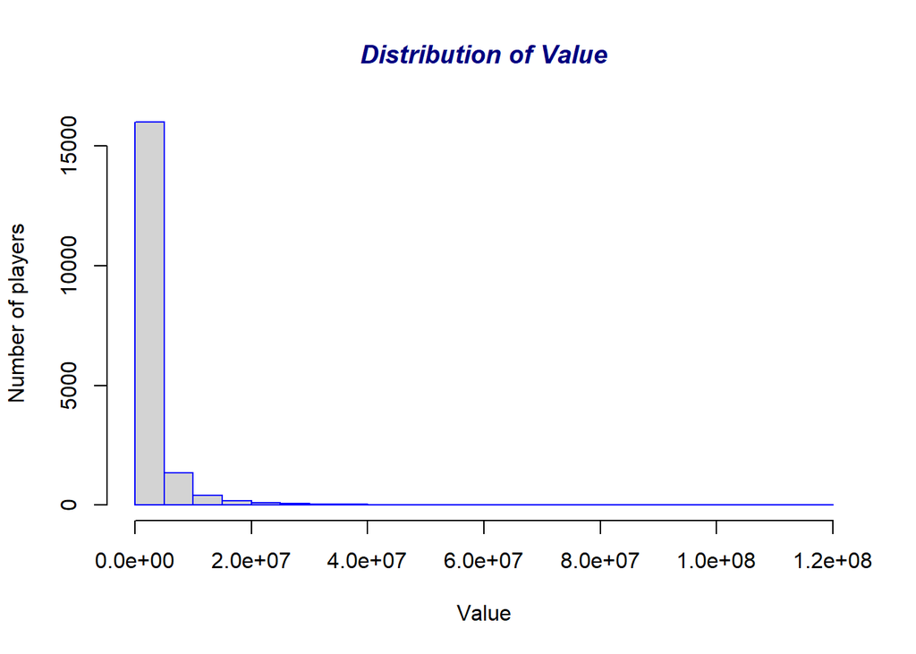

Here we observe that there are some players that do not have any value associated with no value and this might be the free agent players and we also observe that most players are valued in millions with most players being valued less that 20 million euros. The presence of these zero valued players will be an important consideration when doing the regression.

#### Number of Skill Moves of Players Distribution

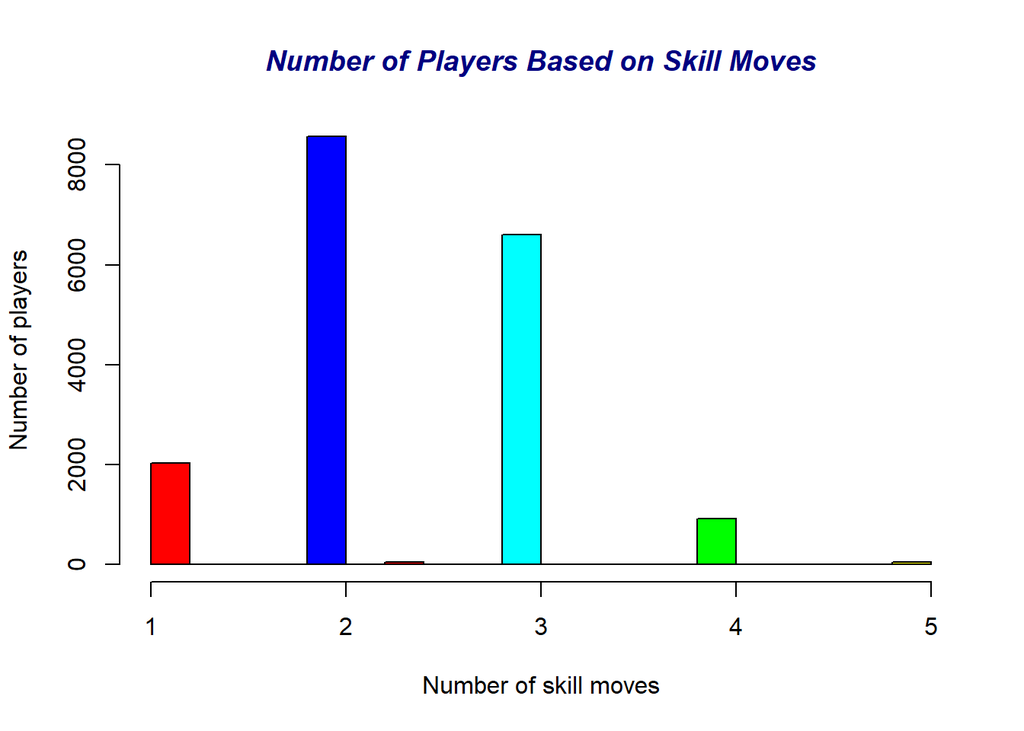

Here we observe that most players have 2 and 3 skill moves while very few players have 5 skill moves

#### Speciality Score Distribution

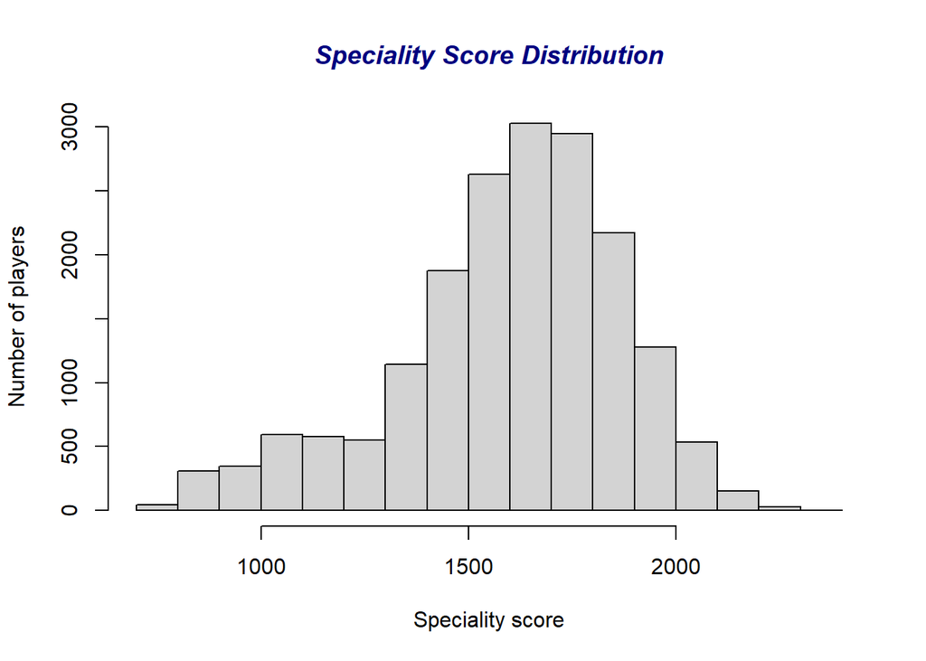

#### Player Overall Rating Distribution

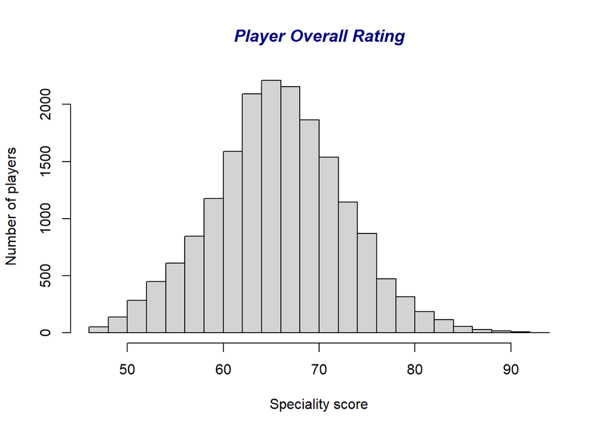

#### Player Potential Rating Distribution

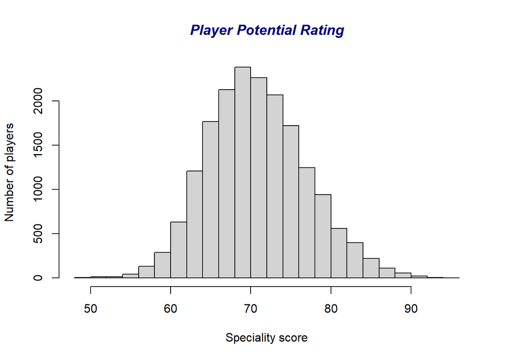

Here we can observe that player potential rating have the a very similar distribution to that of the player overall rating distribution.

### Model Development And Player Selection

In this section we have created a function that makes use of our preferred regression method and the combination of overall and potential ratings to find the value of the players. The value calculated is called the fair value of the players which is then compared to their book value to determine who is under or over valued.

#### Model Development

In this section we develop two functions, one for selecting top 10 undervalued players for a given the position and another one for selecting top 10 overvalued players for a given a position.

```r
#A function to select undervalued players
undervalued<-function(position){
  cols<-c('ID','Name','Overall','Potential','Value','Position')
  pos<-filter(data[cols],Position==position)
  z<-(pos$Potential+pos$Overall)^15
  if (cor(z,pos$Value)<0.94)
  {
    return ('Correlation is below 0.94')
  }else
  {
    pos$x<-z
    fit<-pos%>%
      lm(pos$Value ~ pos$x,data=.)

    coefs<-fit$coefficients

    players<-pos%>%mutate(fair_value=coefs[1]+coefs[2]*x)%>%
      filter(Value<fair_value)%>%
      top_n(10,Value)%>%
      select(-x)
    return (players)
  }

}
#A function to select overvalued players
overvalued<-function(position){
  cols<-c('ID','Name','Overall','Potential','Value','Position')
  pos<-filter(data[cols],Position==position)
  z<-(pos$Potential+pos$Overall)^15
  if (cor(z,pos$Value)<0.94)
  {
    return ('Correlation is below 0.94')
  }else
  {
    pos$x<-z
    fit<-pos%>%
      lm(pos$Value ~ pos$x,data=.)

    coefs<-fit$coefficients

    players<-pos%>%mutate(fair_value=coefs[1]+coefs[2]*x)%>%
      filter(Value>fair_value)%>%
      top_n(10,Value)%>%
      select(-x)
    return (players)
  }

}
```

#### Player Selection

```r
#GK
ogk<-overvalued('GK')
ugk<-undervalued('GK')
ogk
```

```
##        ID          Name Overall Potential    Value Position fair_value
## 1  193080        De Gea      91        93 72000000       GK   70661037
## 2  200389      J. Oblak      90        93 68000000       GK   65100829
## 3  192448 M. ter Stegen      89        92 58000000       GK   55180748
## 4  192119   T. Courtois      89        90 53500000       GK   46682296
## 5  193041      K. Navas      87        87 30500000       GK   30459616
## 6  210257       Ederson      86        90 41500000       GK   36188644
## 7  212831       Alisson      85        90 36500000       GK   33209614
## 8  186153  W. SzczÄ\231sny      85        87 32000000       GK   25582043
## 9  198009      M. Perin      84        89 29500000       GK   27922207
## 10 192563       B. Leno      84        87 27000000       GK   23424806
```

```r
ugk
```

```
##        ID           Name Overall Potential    Value Position fair_value
## 1  167495       M. Neuer      89        89 38000000       GK   42905473
## 2  167948      H. Lloris      88        88 36000000       GK   36188644
## 3  162835 S. HandanoviÄ\215      88        88 30000000       GK   36188644
## 4  206585           Kepa      83        91 28500000       GK   30459616
## 5  192593   D. SubaÅ¡iÄ‡      83        83 13000000       GK   14945675
## 6  163705    S. Mandanda      83        83 13000000       GK   14945675
## 7  104389    R. Jarstein      83        83 13000000       GK   14945675
## 8  230621  G. Donnarumma      82        93 29000000       GK   33209614
## 9  231691      A. Lafont      78        90 14000000       GK   17921593
## 10 225116       A. Meret      75        89 12000000       GK   12431606
```

```r
#CB
ocb<-overvalued('CB')
ucb<-undervalued('CB')
ocb
```

```
##        ID             Name Overall Potential    Value Position fair_value
## 1  205600        S. Umtiti      87        92 57000000       CB   52619968
## 2  177509       M. Benatia      86        86 30000000       CB   28849139
## 3  192366      N. Otamendi      85        85 28500000       CB   24179635
## 4  212190         N. SÃ¼le      84        90 36500000       CB   34344047
## 5  198176       S. de Vrij      84        86 31500000       CB   24179635
## 6  213331           J. Tah      83        88 29500000       CB   26418869
## 7  204639        S. SaviÄ‡      83        86 26000000       CB   22117413
## 8  200724 Nacho FernÃ¡ndez      83        85 24500000       CB   20219136
## 9  211320        D. Rugani      82        86 24500000       CB   20219136
## 10 205452      A. RÃ¼diger      82        84 22500000       CB   16866567
```

```r
ucb
```

```
##        ID         Name Overall Potential    Value Position fair_value
## 1  182493    D. GodÃn      90        90 44000000       CB   57220939
## 2  171919        Naldo      85        85  9000000       CB   24179635
## 3  168609      Miranda      85        85 15500000       CB   24179635
## 4  139720   V. Kompany      85        85 22000000       CB   24179635
## 5  165229 L. Koscielny      82        82 12500000       CB   14034303
## 6  225161      Vallejo      78        86 13500000       CB   14034303
## 7  225100     J. Gomez      78        88 14500000       CB   16866567
## 8  237604    A. Franco      75        85  9500000       CB    9637668
## 9  238476   D. Zagadou      75        85  9000000       CB    9637668
## 10 234986    P. Retsos      75        85  9000000       CB    9637668
## 11 234575  Diogo Leite      74        87  9500000       CB   10598447
```

```r
#LB
olb<-overvalued('LB')
ulb<-undervalued('LB')
olb
```

```
##        ID          Name Overall Potential    Value Position fair_value
## 1  191043   Alex Sandro      86        86 36500000       LB   32150529
## 2  197445      D. Alaba      85        87 38000000       LB   32150529
## 3  212462   Alex Telles      84        87 32000000       LB   29436017
## 4  192638 Marcos Alonso      83        84 24000000       LB   20560398
## 5  205923     B. Davies      81        84 18500000       LB   17117666
## 6  201454    F. Ghoulam      81        82 16500000       LB   14212202
## 7  169595       D. Rose      81        81 14500000       LB   12935899
## 8  211256 N. Tagliafico      80        82 15000000       LB   12935899
## 9  200458      L. Digne      80        84 16000000       LB   15602967
## 10 193352 R. RodrÃguez      80        83 15500000       LB   14212202
```

```r
ulb
```

```
##        ID          Name Overall Potential    Value Position fair_value
## 1  176676       Marcelo      88        88 43000000       LB   45497109
## 2  189332    Jordi Alba      87        87 38000000       LB   38288113
## 3  164169  Filipe LuÃs      85        85 21500000       LB   26934885
## 4  220814 L. HernÃ¡ndez      82        88 25500000       LB   26934885
## 5  216267  A. Robertson      82        87 24500000       LB   24631468
## 6  210035      Grimaldo      81        87 20500000       LB   22511171
## 7  204884      B. Mendy      81        86 20000000       LB   20560398
## 8  211688         GayÃ       80        85 16500000       LB   17117666
## 9  205988       L. Shaw      80        85 16500000       LB   17117666
## 10 202562 J. Roussillon      79        84 14000000       LB   14212202
```

```r
#RB
orb<-overvalued('RB')
urb<-undervalued('RB')
orb
```

```
##        ID             Name Overall Potential    Value Position fair_value
## 1  184432      Azpilicueta      86        86 35000000       RB   31195114
## 2  204963         Carvajal      84        87 31500000       RB   28562234
## 3  188377        K. Walker      84        84 24500000       RB   21845635
## 4  199564    Sergi Roberto      83        86 26500000       RB   23902169
## 5  177457        L. Bender      83        83 20000000       RB   18213566
## 6  203551      A. Florenzi      82        83 20500000       RB   16614326
## 7  193525 MÃ¡rio Fernandes      82        82 18500000       RB   15145178
## 8  186345      K. Trippier      82        82 18500000       RB   15145178
## 9  227928   NÃ©lson Semedo      81        86 20000000       RB   19953526
## 10 210864         E. Hysaj      81        86 20000000       RB   19953526
## 11 210243  Ricardo Pereira      81        85 19000000       RB   18213566
```

```r
urb
```

```
##        ID                Name Overall Potential    Value Position fair_value
## 1  210514       JoÃ£o Cancelo      82        88 25500000       RB   26136317
## 2  234035           Odriozola      80        88 18500000       RB   21845635
## 3  226851           B. Pavard      80        86 17500000       RB   18213566
## 4  203747   HÃ©ctor BellerÃn      80        85 16500000       RB   16614326
## 5  231281 T. Alexander-Arnold      78        88 14000000       RB   18213566
## 6  228881         D. Calabria      78        88 14500000       RB   18213566
## 7  216643           L. Dubois      77        84 10500000       RB   11422878
## 8  226166          N. Mukiele      77        86 12000000       RB   13796236
## 9  226229           T. Kehrer      77        84 11000000       RB   11422878
## 10 210625            K. Mbabu      77        83 10000000       RB   10382000
```

```r
#LCB
olcb<-overvalued('LCB')
ulcb<-undervalued('LCB')
olcb
```

```
##        ID              Name Overall Potential    Value Position fair_value
## 1  178603        M. Hummels      88        88 46000000      LCB   42481917
## 2  201024      K. Koulibaly      87        90 51000000      LCB   46265635
## 3  203376       V. van Dijk      86        88 44500000      LCB   35761754
## 4  232363      M. Å kriniar      85        92 46500000      LCB   46265635
## 5  192774        K. Manolas      85        87 37500000      LCB   30040351
## 6  212218        A. Laporte      84        88 34000000      LCB   30040351
## 7  230375 JosuÃ© Chiamulera      83        83 22500000      LCB   17563867
## 8  225850       P. Kimpembe      83        89 30500000      LCB   30040351
## 9  220440        C. Lenglet      82        88 26000000      LCB   25178373
## 10 203263        H. Maguire      82        85 23500000      LCB   19236132
```

```r
ulcb
```

```
##        ID           Name Overall Potential    Value Position fair_value
## 1  138956   G. Chiellini      89        89 27000000      LCB   50360773
## 2  172871  J. Vertonghen      87        87 34000000      LCB   35761754
## 3  179944     David Luiz      83        83 17500000      LCB   17563867
## 4  210413   A. Romagnoli      82        89 26500000      LCB   27509907
## 5  181786    V. Ä†orluka      82        82 12500000      LCB   14614858
## 6  168530         Jardel      82        82 12500000      LCB   14614858
## 7  229237      M. Akanji      81        87 21000000      LCB   21054626
## 8  213661 A. Christensen      81        88 21500000      LCB   23031148
## 9  225711      A. Diallo      79        86 15000000      LCB   16026848
## 10 240130 Ã‰der MilitÃ£o      78        87 14000000      LCB   16026848
## 11 220523        Y. Mina      78        85 12500000      LCB   13318399
## 12 229558   D. Upamecano      77        88 13000000      LCB   16026848
```

```r
#RCB
orcb<-overvalued('RCB')
urcb<-undervalued('RCB')
orcb
```

```
##        ID            Name Overall Potential    Value Position fair_value
## 1  152729          PiquÃ©      87        87 34000000      RCB   33713905
## 2  201535       R. Varane      86        91 50000000      RCB   43538473
## 3  184344      L. Bonucci      86        86 30000000      RCB   28362520
## 4  184087 T. Alderweireld      86        87 39000000      RCB   30930010
## 5  183907      J. Boateng      85        85 30000000      RCB   23814978
## 6  220793     D. SÃ¡nchez      84        88 34000000      RCB   28362520
## 7  216460     J. GimÃ©nez      84        88 34000000      RCB   28362520
## 8  172879        Sokratis      84        84 23000000      RCB   19957924
## 9  203574       J. Stones      83        87 28500000      RCB   23814978
## 10 192227      S. Mustafi      82        84 22500000      RCB   16692921
```

```r
urcb
```

```
##        ID           Name Overall Potential    Value Position fair_value
## 1  155862   Sergio Ramos      91        91 51000000      RCB   66069151
## 2  164240   Thiago Silva      88        88 24000000      RCB   39999458
## 3  120533           Pepe      85        85  9000000      RCB   23814978
## 4  157481   RaÃºl Albiol      84        84 18000000      RCB   19957924
## 5  235243     M. de Ligt      82        91 27000000      RCB   30930010
## 6  230225 Juiano Mestres      82        82  6500000      RCB   13934632
## 7  183280        A. Rami      82        82 12500000      RCB   13934632
## 8  159147      L. Perrin      80        80  8500000      RCB    9652834
## 9  237678     I. KonatÃ©      74        84  7500000      RCB    8010500
## 10 241486     J. KoundÃ©      73        86  6500000      RCB    8795540
```

```r
#LWB
olwb<-overvalued('LWB')
ulwb<-overvalued('LWB')
olwb
```

```
##        ID          Name Overall Potential    Value Position fair_value
## 1  200536     N. Schulz      80        81 14500000      LWB   13687706
## 2  223682       Granell      79        79 12000000      LWB   10250308
## 3  201884      R. Brady      77        78 10500000      LWB    7615033
## 4  186115      K. Gibbs      76        76  6000000      LWB    5605060
## 5  179696     E. InsÃºa      76        76  6000000      LWB    5605060
## 6  192087 G. Schennikov      75        76  6000000      LWB    5048880
## 7  215322      J. Silva      74        79  6500000      LWB    6214897
## 8  209818     J. Brenet      74        77  6000000      LWB    5048880
## 9  218540     A. Oyongo      74        75  5000000      LWB    4080184
## 10 203544      C. LÃ¶we      73        73  3000000      LWB    2929740
```

```r
ulwb
```

```
##        ID          Name Overall Potential    Value Position fair_value
## 1  200536     N. Schulz      80        81 14500000      LWB   13687706
## 2  223682       Granell      79        79 12000000      LWB   10250308
## 3  201884      R. Brady      77        78 10500000      LWB    7615033
## 4  186115      K. Gibbs      76        76  6000000      LWB    5605060
## 5  179696     E. InsÃºa      76        76  6000000      LWB    5605060
## 6  192087 G. Schennikov      75        76  6000000      LWB    5048880
## 7  215322      J. Silva      74        79  6500000      LWB    6214897
## 8  209818     J. Brenet      74        77  6000000      LWB    5048880
## 9  218540     A. Oyongo      74        75  5000000      LWB    4080184
## 10 203544      C. LÃ¶we      73        73  3000000      LWB    2929740
```

```r
#RWB
orwb<-overvalued('RWB')
urwb<-undervalued('RWB')
orwb
```

```
##        ID           Name Overall Potential    Value Position fair_value
## 1  207862      M. Ginter      80        82 15500000      RWB   13543473
## 2  203605 P. KadeÅ\231Ã¡bek      80        81 14000000      RWB   12327999
## 3  204105        K. Lala      77        78  8500000      RWB    6904377
## 4  223597     R. Aguilar      77        81  9500000      RWB    9257992
## 5  207920        E. Durm      75        77  6500000      RWB    5109232
## 6  189234       M. Risse      75        75  6500000      RWB    4159745
## 7  201417     M. Doherty      75        78  7000000      RWB    5653889
## 8  192667        A. Nyom      74        74  4100000      RWB    3371910
## 9  220620 F. Hadergjonaj      74        80  6500000      RWB    6250734
## 10 201982      J. Schmid      74        74  5500000      RWB    3371910
```

```r
urwb
```

```
##        ID         Name Overall Potential   Value Position fair_value
## 1  180216   S. Coleman      80        80 1.1e+07      RWB   11213749
## 2  197083 D. Caligiuri      79        79 9.0e+06      RWB    9257992
## 3  221342 Pablo Maffeo      78        86 1.3e+07      RWB   16312685
## 4  169426    BarragÃ¡n      76        76 5.0e+06      RWB    5109232
## 5  240754      Y. Atal      73        82 5.5e+06      RWB    6904377
## 6  229039  Johannesson      70        75 2.0e+06      RWB    2437727
## 7  234279   C. Rizzuto      69        71 1.0e+06      RWB    1374500
## 8  243576  Pedro Porro      69        82 1.6e+06      RWB    4612497
## 9  213933 L. Wahlqvist      69        76 1.3e+06      RWB    2437727
## 10 227600 J. Andersson      68        76 1.1e+06      RWB    2181567
```

```r
#CDM
ocdm<-overvalued('CDM')
ucdm<-undervalued('CDM')
ocdm
```

```
##        ID             Name Overall Potential    Value Position fair_value
## 1  200145         Casemiro      88        90 59500000      CDM   55193146
## 2  180206       M. PjaniÄ‡      86        86 44000000      CDM   32848921
## 3  209499          Fabinho      84        88 34000000      CDM   32848921
## 4  207566 William Carvalho      84        86 31500000      CDM   27502716
## 5  191202        N. MatiÄ‡      84        84 24000000      CDM   22968266
## 6  178562        E. Banega      84        84 29000000      CDM   22968266
## 7  200888   Danilo Pereira      83        86 27000000      CDM   25141640
## 8  189712     K. Strootman      83        83 21000000      CDM   19129847
## 9  177610   Javi MartÃnez      83        83 20000000      CDM   19129847
## 10 187936        S. Nzonzi      82        82 17000000      CDM   15887133
## 11 183376         L. Fejsa      82        82 17000000      CDM   15887133
## 12 204024        C. Kramer      81        82 17000000      CDM   14461554
```

```r
ucdm
```

```
##        ID            Name Overall Potential    Value Position fair_value
## 1  189511 Sergio Busquets      89        89 51500000      CDM   55193146
## 2  135507     Fernandinho      86        86 18000000      CDM   32848921
## 3  209989       T. Partey      82        88 25500000      CDM   27502716
## 4  158963       L. Biglia      82        82 12500000      CDM   15887133
## 5  226161 Marcos Llorente      79        87 16000000      CDM   19129847
## 6  232244   S. AscacÃbar      78        84 12000000      CDM   13153302
## 7  214394      W. Barrios      78        85 12500000      CDM   14461554
## 8  230936         A. Nagy      76        83  9500000      CDM    9845487
## 9  239641     Alfa Semedo      76        85 10500000      CDM   11953357
## 10 235945       Marc Roca      76        87 11500000      CDM   14461554
```

```r
#LDM
oldm<-overvalued('LDM')
uldm<-undervalued('LDM')
oldm
```

```
##        ID         Name Overall Potential    Value Position fair_value
## 1  187961     Paulinho      85        85 37000000      LDM   29017094
## 2  216451      J. Seri      81        82 20500000      LDM   15292188
## 3  216352 M. BrozoviÄ‡      81        84 18500000      LDM   18426529
## 4  199503     G. Xhaka      81        84 22000000      LDM   18426529
## 5  199042 C. ArÃ¡nguiz      81        81 17000000      LDM   13915344
## 6  211575 AndrÃ© Gomes      80        85 19500000      LDM   18426529
## 7  207939   G. Pizarro      79        79 10000000      LDM    9462801
## 8  187052    Y. M'Vila      79        80 11500000      LDM   10434102
## 9  222709       Petros      78        78 10000000      LDM    7760752
## 10 187924   C. Grenier      77        78 10000000      LDM    7017435
## 11 231102      L. Blas      75        84 10500000      LDM   10434102
```

```r
uldm
```

```
##        ID          Name Overall Potential    Value Position fair_value
## 1  215914     N. KantÃ©      89        90 63000000      LDM   63286180
## 2  207865    Marquinhos      84        89 35500000      LDM   37820259
## 3  176266   Lucas Leiva      83        83 17500000      LDM   20205238
## 4  228702    F. de Jong      81        89 26000000      LDM   29017094
## 5  226790      W. Ndidi      80        85 17000000      LDM   18426529
## 6  176915 A. FernÃ¡ndez      80        80 11000000      LDM   11494800
## 7  213160     R. Zobnin      79        86 15000000      LDM   18426529
## 8  205201   O. YokuÅŸlu      77        83 10500000      LDM   11494800
## 9  220905     J. Aholou      76        83  9500000      LDM   10434102
## 10 237629      A. Maier      73        86  7500000      LDM   10434102
```

```r
#RDM
ordm<-overvalued('RDM')
urdm<-undervalued('RDM')
ordm
```

```
##        ID          Name Overall Potential    Value Position fair_value
## 1  195864      P. Pogba      87        91 64000000      RDM   59688755
## 2  190584  Illarramendi      84        84 31000000      RDM   24841627
## 3  193474      I. Gueye      83        83 21000000      RDM   20690862
## 4  210896     M. Sanson      80        85 19500000      RDM   18863235
## 5  206413 T. Stepanenko      80        80 12000000      RDM   11740871
## 6  215057    I. Marcone      79        80 11500000      RDM   10651001
## 7  187735    A. Dzagoev      79        79 12500000      RDM    9652988
## 8  196934   O. Ã–zyakup      78        81 13000000      RDM   10651001
## 9  213051     M. Elneny      77        79  9000000      RDM    7904130
## 10 190674     B. AndrÃ©      77        77  9000000      RDM    6442568
## 11 212212       D. Kohr      77        81 10000000      RDM    9652988
## 12 202024    R. Freuler      76        77  9000000      RDM    5805402
## 13 204497    K. StÃ¶ger      75        80  9000000      RDM    7140369
```

```r
urdm
```

```
##        ID         Name Overall Potential    Value Position fair_value
## 1   53302  D. De Rossi      83        83  8000000      RDM   20690862
## 2  183498    M. Parolo      82        82  9000000      RDM   17184277
## 3  208135 A. DoucourÃ©      81        85 19500000      RDM   20690862
## 4  147782   I. Denisov      80        80  4500000      RDM   11740871
## 5  227234   L. Tousart      79        84 14500000      RDM   15642694
## 6  180432     Hernanes      78        78  6000000      RDM    7904130
## 7  224574    O. Pineda      75        83  9500000      RDM    9652988
## 8  236792   T. SouÄ\215ek      75        83  8500000      RDM    9652988
## 9  195698 C. DoukourÃ©      73        78  4500000      RDM    4693656
## 10 244376  V. Shepelev      73        82  5500000      RDM    7140369
## 11 232099   M. GrujiÄ‡      73        84  6000000      RDM    8739599
```

```r
#CAM
ocam<-overvalued('CAM')
ucam<-undervalued('CAM')
ocam
```

```
##        ID            Name Overall Potential    Value Position fair_value
## 1  194765    A. Griezmann      89        90 78000000      CAM   73368630
## 2  190460      C. Eriksen      88        91 73500000      CAM   73368630
## 3  201942 Roberto Firmino      86        87 53000000      CAM   43779570
## 4  189596      T. MÃ¼ller      86        86 45000000      CAM   40088583
## 5  176635        M. Ã–zil      86        86 43500000      CAM   40088583
## 6  216594        N. Fekir      85        89 50000000      CAM   47781658
## 7  178518   R. Nainggolan      85        85 35500000      CAM   33551102
## 8  184942        Giuliano      83        83 26000000      CAM   23312535
## 9  207494      J. Lingard      82        83 26500000      CAM   21245838
## 10 186561       A. Ramsey      82        83 25000000      CAM   21245838
```

```r
ucam
```

```
##        ID             Name Overall Potential    Value Position fair_value
## 1  181872         A. Vidal      85        85 26000000      CAM   33551102
## 2  177388         D. Payet      84        84 27500000      CAM   28006256
## 3  212523 Anderson Talisca      83        90 36500000      CAM   43779570
## 4  201400          Rafinha      82        87 29500000      CAM   30663915
## 5  226456    Pablo Fornals      81        86 24000000      CAM   25561085
## 6  188988       M. Lanzini      81        85 23000000      CAM   23312535
## 7  235790       K. Havertz      80        89 22000000      CAM   30663915
## 8  230142        Oyarzabal      80        87 21000000      CAM   25561085
## 9  225663       A. Golovin      79        85 17000000      CAM   19347259
## 10 225309         N. Amiri      78        85 14500000      CAM   17604022
```

```r
#CM
ocm<-overvalued('CM')
ucm<-undervalued('CM')
ocm
```

```
##        ID                  Name Overall Potential    Value Position fair_value
## 1  189509                Thiago      86        86 45500000       CM   37120885
## 2  223848 S. MilinkoviÄ‡-SaviÄ‡      85        90 50500000       CM   48213706
## 3  205498              Jorginho      84        87 38000000       CM   33983602
## 4  186942         I. GÃ¼ndoÄŸan      84        84 32000000       CM   25980247
## 5  220971             N. KeÃ¯ta      83        88 34000000       CM   33983602
## 6  219683            C. Tolisso      83        88 34000000       CM   33983602
## 7  210008             A. Rabiot      83        87 33000000       CM   31092931
## 8  209658           L. Goretzka      83        88 34000000       CM   33983602
## 9  202166            J. Draxler      83        86 32500000       CM   28430769
## 10 231866                 Rodri      82        87 29000000       CM   28430769
```

```r
ucm
```

```
##        ID                  Name Overall Potential    Value Position fair_value
## 1  235569           T. Ndombele      80        89 22500000       CM   28430769
## 2  218339             M. Dahoud      80        86 20000000       CM   21652351
## 3  208333                E. Can      80        85 19500000       CM   19746732
## 4  198784 A. Oxlade-Chamberlain      80        85 19500000       CM   19746732
## 5  230938            F. KessiÃ©      79        88 19500000       CM   23725651
## 6  205192         Denis SuÃ¡rez      79        86 17500000       CM   19746732
## 7  228251         L. Pellegrini      78        84 14000000       CM   14913675
## 8  216435            S. Lobotka      78        84 14000000       CM   14913675
## 9  216393          Y. Tielemans      78        87 16000000       CM   19746732
## 10 208450       Andreas Pereira      78        84 14000000       CM   14913675
## 11 208268          B. Cristante      78        86 15000000       CM   17996126
## 12 230613            A. Diawara      77        87 14000000       CM   17996126
```

```r
#LAM
olam<-overvalued('LAM')
ulam<-undervalued('LAM')
olam
```

```
##        ID             Name Overall Potential    Value Position fair_value
## 1  198710    J. RodrÃguez      88        89 69500000      LAM   69482940
## 2  230408   Fabrio Farinha      75        75  7000000      LAM    5242231
## 3  230276 NicolÃ¡s Formido      74        74  5500000      LAM    4174631
## 4  227886      D. Buitrago      72        73  3600000      LAM    2908713
## 5  230461   Leordinho Paes      72        72  2900000      LAM    2561589
## 6  236175    Marlion Rolim      71        71  2500000      LAM    1961029
## 7  234017   Allan ArdaÃºjo      70        70  1700000      LAM    1467926
## 8  230474  Macarinho Louro      70        70  1700000      LAM    1467926
## 9  230489   Diogildo Peixe      70        70  1700000      LAM    1467926
## 10 236172   Nilson Padilho      70        70  1700000      LAM    1467926
```

```r
ulam
```

```
##       ID              Name Overall Potential    Value Position fair_value
## 1 199434         D. TadiÄ‡      81        81 17500000      LAM 17958186.2
## 2 230487   Leo Caldeirinha      74        74  2800000      LAM  4174631.1
## 3 230484 AdriÃ¡n BurnabÃ£o      72        72  1600000      LAM  2561588.7
## 4 230486     Paulolettinho      71        71  1200000      LAM  1961029.0
## 5 230266     Heltinho Melo      71        71  1200000      LAM  1961029.0
## 6 236165    Paulo Daineiro      69        69   525000      LAM  1064191.0
## 7 225939         J. George      69        70  1200000      LAM  1255901.6
## 8 168730     D. Guastavino      68        68   550000      LAM   734583.4
## 9 244391         F. Sakala      66        75  1000000      LAM  1702248.0
```

```r
#LCM
olcm<-overvalued('LCM')
ulcm<-undervalued('LCM')
olcm
```

```
##        ID            Name Overall Potential    Value Position fair_value
## 1  182521        T. Kroos      90        90 76500000      LCM   72280019
## 2  171877     M. HamÅ¡Ãk      87        87 46500000      LCM   43390296
## 3  199556     M. Verratti      86        89 55000000      LCM   47302626
## 4  212198 Bruno Fernandes      84        88 40500000      LCM   36451139
## 5  197965           Pizzi      83        83 25500000      LCM   21319137
## 6  195365        K. Kampl      83        83 26500000      LCM   21319137
## 7  188152           Oscar      83        84 30500000      LCM   23347330
## 8  216354    A. KramariÄ‡      82        83 26000000      LCM   19454976
## 9  207471     F. VÃ¡zquez      82        82 21500000      LCM   17742456
## 10 193283      T. Delaney      82        83 21500000      LCM   19454976
```

```r
ulcm
```

```
##        ID          Name Overall Potential    Value Position fair_value
## 1  168542   David Silva      90        90 60000000      LCM   72280019
## 2  211117       D. Alli      84        90 42500000      LCM   43390296
## 3  177413     A. Witsel      84        84 24000000      LCM   25552876
## 4  207410  M. KovaÄ\215iÄ‡      83        89 35000000      LCM   36451139
## 5  230658        Arthur      82        90 32500000      LCM   36451139
## 6  223959   L. Torreira      82        87 25000000      LCM   27950085
## 7  222509 Dani Ceballos      81        88 25000000      LCM   27950085
## 8  224293  RÃºben Neves      80        87 20500000      LCM   23347330
## 9  219809   T. Bakayoko      80        85 17000000      LCM   19454976
## 10 232097      A. Harit      79        86 18000000      LCM   19454976
```

```r
#LM
olm<-overvalued('LM')
ulm<-undervalued('LM')
olm
```

```
##        ID          Name Overall Potential    Value Position fair_value
## 1  188567 P. Aubameyang      88        88 59000000       LM   56168850
## 2  208722      S. ManÃ©      86        87 52000000       LM   43310952
## 3  190483 Douglas Costa      86        86 46500000       LM   39670980
## 4  188350       M. Reus      86        86 43500000       LM   39670980
## 5  193747          Koke      85        86 45000000       LM   36315539
## 6  184267    Y. Brahimi      85        85 39000000       LM   33223859
## 7  181458  I. PeriÅ¡iÄ‡      85        85 37500000       LM   33223859
## 8  200104        H. Son      84        85 37000000       LM   30376578
## 9  213345      K. Coman      83        87 34000000       LM   33223859
## 10 208418   Y. Carrasco      83        86 33000000       LM   30376578
```

```r
ulm
```

```
##        ID           Name Overall Potential    Value Position fair_value
## 1  170890     B. Matuidi      85        85 26000000       LM   33223859
## 2  213565       T. Lemar      83        89 35500000       LM   39670980
## 3  212194      J. Brandt      82        88 30500000       LM   33223859
## 4  229906      L. Bailey      81        89 26500000       LM   33223859
## 5  226271        FabiÃ¡n      81        89 26000000       LM   33223859
## 6  209889   R. Guerreiro      81        86 24000000       LM   25344279
## 7  139068           Nani      81        81 15500000       LM   15919543
## 8  234906       H. Aouar      80        90 23500000       LM   33223859
## 9  213516  Ricardo Horta      79        84 17000000       LM   17497197
## 10 203362 M. Elyounoussi      79        85 17500000       LM   19216339
```

```r
#RM
orm<-overvalued('RM')
urm<-undervalued('RM')
orm
```

```
##        ID            Name Overall Potential    Value Position fair_value
## 1  209331        M. Salah      88        89 69500000       RM   56932214
## 2  204970      F. Thauvin      84        87 39000000       RM   33870174
## 3  185020 JosÃ© CallejÃ³n      84        84 27500000       RM   25932762
## 4  183898    A. Di MarÃa      84        84 29500000       RM   25932762
## 5  208808       Q. Promes      83        84 30500000       RM   23696742
## 6  200949     Lucas Moura      83        84 31000000       RM   23696742
## 7  192883   H. Mkhitaryan      83        83 25500000       RM   21640525
## 8  227055  Gelson Martins      82        87 29500000       RM   28363093
## 9  212404 F. Bernardeschi      82        87 29500000       RM   28363093
## 10 210617 Samu Castillejo      82        86 29000000       RM   25932762
```

```r
urm
```

```
##        ID         Name Overall Potential    Value Position fair_value
## 1  231747   K. MbappÃ©      88        95 81000000       RM   93980476
## 2   20775     Quaresma      84        84 15500000       RM   25932762
## 3    9014    A. Robben      84        84 15500000       RM   25932762
## 4  214997    A. Correa      81        87 24500000       RM   25932762
## 5  234153 Carlos Soler      80        87 21000000       RM   23696742
## 6  244369 V. Tsygankov      79        86 18000000       RM   19750606
## 7  233419     Raphinha      79        86 18000000       RM   19750606
## 8  227796   C. Pulisic      79        87 18000000       RM   21640525
## 9  210411      OtÃ¡vio      79        85 17500000       RM   18014425
## 10 233049    J. Sancho      77        89 14500000       RM   21640525
```

```r
#RAM
oram<-overvalued('RAM')
uram<-undervalued('RAM')
oram
```

```
##        ID              Name Overall Potential    Value Position fair_value
## 1  208670         H. Ziyech      83        86 32500000      RAM   32456804
## 2  230465    Allan Bardinho      75        75  7000000      RAM    5229587
## 3  230267    Sebas Couteira      74        74  5500000      RAM    4233148
## 4  230277 Gustavo Lobateiro      73        73  3800000      RAM    3408438
## 5  230478        Jairinhazo      72        72  2900000      RAM    2727625
## 6  230281      Mauro Riboas      72        72  3300000      RAM    2727625
## 7  199651 Fernando CanesÃn      72        74  3800000      RAM    3408438
## 8  230459    Tiago Pombeira      71        71  2200000      RAM    2167096
## 9  230263   Adeilson Gesser      71        71  2500000      RAM    2167096
## 10 230522     Nascimentardo      71        71  2200000      RAM    2167096
## 11 230275   Emerson Avintes      71        71  2500000      RAM    2167096
```

```r
uram
```

```
##       ID              Name Overall Potential    Value Position fair_value
## 1 193082       J. Cuadrado      84        84 29500000      RAM   29672388
## 2 230483      Jacson Zonta      74        74  2800000      RAM    4233148
## 3 230272   KauÃ£ Abranches      74        74  2800000      RAM    4233148
## 4 230257 Clayton Fildeiras      72        72  1600000      RAM    2727625
## 5 172613         L. Seijas      71        71  1800000      RAM    2167096
## 6 221480        Y. Cabrera      69        69  1100000      RAM    1330037
## 7 201971         A. Ienaga      69        69   825000      RAM    1330037
## 8 229923         S. Stolze      66        72   875000      RAM    1330037
```

```r
#RCM
orcm<-overvalued('RCM')
urcm<-undervalued('RCM')
orcm
```

```
##        ID           Name Overall Potential    Value Position fair_value
## 1  192985   K. De Bruyne      91        92 1.02e+08      RCM   92208977
## 2  168651    I. RakitiÄ‡      87        87 4.65e+07      RCM   43162950
## 3  212622     J. Kimmich      85        88 4.05e+07      RCM   39570414
## 4  208421          SaÃºl      85        90 5.05e+07      RCM   47056476
## 5  189513         Parejo      85        85 3.70e+07      RCM   30388673
## 6  179846     S. Khedira      85        85 3.30e+07      RCM   30388673
## 7  206545 Manu Trigueros      83        84 3.00e+07      RCM   23216311
## 8  199914          Allan      83        83 2.65e+07      RCM   21197866
## 9  216194   Dani GarcÃa      82        83 2.00e+07      RCM   19342664
## 10 198950  Pablo Sarabia      82        83 2.60e+07      RCM   19342664
```

```r
urcm
```

```
##        ID             Name Overall Potential    Value Position fair_value
## 1  177003       L. ModriÄ‡      91        91 67000000      RCM   84916451
## 2  230258 Rosberto Dourado      82        82 16500000      RCM   17638375
## 3  210406    P. ZieliÅ„ski      81        88 24500000      RCM   27796945
## 4  226226      G. Lo Celso      80        86 20000000      RCM   21197866
## 5  214947        J. Gbamin      79        84 14500000      RCM   16073532
## 6  213991         J. Lerma      79        84 14500000      RCM   16073532
## 7  226168     M. Eggestein      78        84 14000000      RCM   14637478
## 8  227535     R. Bentancur      77        89 15500000      RCM   21197866
## 9  224232       N. Barella      77        89 15500000      RCM   21197866
## 10 238359           Wendel      76        86 12500000      RCM   14637478
```

```r
#CF
ocf<-overvalued('CF')
ucf<-undervalued('CF')
ocf
```

```
##        ID            Name Overall Potential    Value Position fair_value
## 1  198706    Luis Alberto      82        85 28500000       CF   24750103
## 2  184431     S. Giovinco      82        82 20000000       CF   18792001
## 3  187072       L. Stindl      81        81 18000000       CF   15586577
## 4  192064 Ricardo Goulart      79        80 14500000       CF   11708156
## 5  215590    Ayoze PÃ©rez      76        81 10500000       CF    9635677
## 6  191565       Y. ÅŒsako      76        76  8000000       CF    5823758
## 7  213582         A. Ruiz      76        79 10000000       CF    7901678
## 8  170369   G. dos Santos      75        75  6500000       CF    4724706
## 9  228666        B. Kuwas      74        75  6500000       CF    4247333
## 10 208451      R. Quaison      74        78  7500000       CF    5823758
```

```r
ucf
```

```
##        ID         Name Overall Potential    Value Position fair_value
## 1  205175     A. Milik      81        88 25500000       CF   29642931
## 2  144622      Raffael      81        81 11000000       CF   15586577
## 3  229517   Toni Villa      73        82  6000000       CF    7901678
## 4  215202    L. Janson      73        79  5500000       CF    5823758
## 5  232730    D. Kamada      72        79  4500000       CF    5248777
## 6  234889    F. Jensen      71        80  3700000       CF    5248777
## 7  214000     Y. Reyna      70        75  2400000       CF    2731433
## 8  241994  Y. Toyokawa      69        74  1400000       CF    2165880
## 9  221662    S. Skrabb      68        76  1300000       CF    2434922
## 10 246239 J. MatouÅ¡ek      68        83  2000000       CF    5248777
## 11 226266    J. Vargas      67        77  1300000       CF    2434922
```

```r
#LF
olf<-overvalued('LF')
ulf<-undervalued('LF')
olf
```

```
##        ID           Name Overall Potential    Value Position  fair_value
## 1  183277      E. Hazard      91        91 93000000       LF 84768728.85
## 2  198164 Jonathan Viera      82        82 22500000       LF 17533037.89
## 3  190577      S. Blanco      76        76  7500000       LF  5399902.61
## 4  204713    J. Campbell      76        77  9000000       LF  5989756.81
## 5  198145      S. Araujo      73        76  5000000       LF  3924994.26
## 6  177105       P. Ebert      71        71  2100000       LF  1749336.72
## 7  219771 Gabriel Xavier      70        74  2300000       LF  2229295.28
## 8  186241      H. Ojamaa      66        66   675000       LF   380777.23
## 9  212976         T. Abe      64        64   425000       LF   126560.63
## 10 232741    T. Matsuura      62        62   300000       LF   -37643.81
```

```r
ulf
```

```
##       ID           Name Overall Potential    Value Position fair_value
## 1 211110      P. Dybala      89        94 89000000       LF   92056661
## 2     41        Iniesta      86        86 21500000       LF   36140076
## 3 204350  A. Trajkovski      69        72  1300000       LF    1542523
## 4 241947       F. Amuzu      67        81  1600000       LF    3518415
## 5 245058 O. Kiteishvili      66        77  1100000       LF    1977579
```

```r
#LS
ols<-overvalued('LS')
uls<-undervalued('LS')
ols
```

```
##        ID           Name Overall Potential    Value Position fair_value
## 1  167664    G. HiguaÃn      88        88 57000000       LS   55825215
## 2  179844    Diego Costa      85        85 38500000       LS   33103077
## 3  143076      A. GÃ³mez      84        84 30000000       LS   27687980
## 4  208093  Gerard Moreno      83        85 32000000       LS   27687980
## 5  186627   M. Balotelli      83        83 27500000       LS   23104092
## 6  198717        W. Zaha      82        85 28500000       LS   25300026
## 7  184200 M. ArnautoviÄ‡      82        82 22000000       LS   19231603
## 8  216475        Morales      81        81 17000000       LS   15966828
## 9  207877   J. MartÃnez      81        84 22500000       LS   21085756
## 10 207664       C. Bacca      81        81 16000000       LS   15966828
```

```r
uls
```

```
##        ID            Name Overall Potential    Value Position fair_value
## 1  179813       E. Cavani      89        89 60000000       LS   66171331
## 2  208596      A. Belotti      82        87 30000000       LS   30283450
## 3  221992       H. Lozano      81        86 24000000       LS   25300026
## 4  212623      Santi Mina      80        85 20000000       LS   21085756
## 5  150418       M. GÃ³mez      80        80 12000000       LS   13220189
## 6   49369 Fernando Torres      80        80  8000000       LS   13220189
## 7  164029         Charles      79        79  6500000       LS   10914441
## 8  232432       L. JoviÄ‡      78        86 15500000       LS   19231603
## 9  219455      J. Calleri      77        82 12000000       LS   12016594
## 10 232381          Wesley      77        85 13500000       LS   15966828
```

```r
#RF
orf<-overvalued('RF')
urf<-undervalued('RF')
orf
```

```
##       ID        Name Overall Potential    Value Position fair_value
## 1 175943  D. Mertens      87        87 45000000       RF   36008772
## 2 172114   D. Valeri      80        80 11500000       RF   10789000
## 3 201313    C. Ciano      75        75  6500000       RF    4580188
## 4 221820 Zhang Xizhe      72        72  3300000       RF    2839030
## 5 220084 C. Falletti      72        75  3900000       RF    3586131
```

```r
urf
```

```
##        ID               Name Overall Potential     Value Position fair_value
## 1  158023           L. Messi      94        94 110500000       RF  113252153
## 2  150516        L. Podolski      78        78   6500000       RF    7625673
## 3  216334         P. Gerkens      72        77   4200000       RF    4217193
## 4  231628           Rafa Mir      70        81   3100000       RF    4978693
## 5  224385          H. Yamada      69        69   1000000       RF    1866426
## 6  209039 D. Moberg Karlsson      69        75   1500000       RF    2839030
## 7  213717         P. Forsell      69        69   1100000       RF    1866426
## 8  206605          A. Aosman      68        73   1200000       RF    2280863
## 9  232609         G. Notsuda      66        70    850000       RF    1652336
## 10 207659        L. Grozurek      65        66    625000       RF    1276420
```

```r
#RS
ors<-overvalued('RS')
urs<-undervalued('RS')
ors
```

```
##        ID          Name Overall Potential    Value Position fair_value
## 1  167397        Falcao      84        84 25000000       RS   24417340
## 2  199451 W. Ben Yedder      82        82 23500000       RS   17066019
## 3  202685       S. Zaza      81        82 21000000       RS   15586045
## 4  227536     M. Marega      80        80 16000000       RS   11840160
## 5  205693     S. Haller      80        83 19000000       RS   15586045
## 6  202477      Deulofeu      80        82 18500000       RS   14227876
## 7  194879  Sergi Enrich      80        80 15500000       RS   11840160
## 8  207732         Roger      79        80 14500000       RS   10793848
## 9  183580   N. Petersen      79        79 12500000       RS    9835721
## 10 242348         Loren      78        83 14000000       RS   12982146
## 11 205431  N. FÃ¼llkrug      78        79 12500000       RS    8958836
## 12 212626      D. Selke      77        83 12500000       RS   11840160
```

```r
urs
```

```
##        ID             Name Overall Potential   Value Position fair_value
## 1  176580       L. SuÃ¡rez      91        91 8.0e+07       RS   80695274
## 2   41236  Z. IbrahimoviÄ‡      85        85 1.4e+07       RS   29124806
## 3  159261  F. Quagliarella      81        81 8.0e+06       RS   14227876
## 4  216388 A. Saint-Maximin      79        86 1.8e+07       RS   18677876
## 5  237715       P. Cutrone      77        89 1.6e+07       RS   20432462
## 6  209780    S. Schrijvers      73        79 5.5e+06       RS    5583690
## 7  236461        J. Mateta      73        84 7.0e+06       RS    8958836
## 8  231416     D. Lukebakio      73        81 6.0e+06       RS    6753606
## 9  228144      Jorge Pombo      72        79 4.4e+06       RS    5074590
## 10 235866       C. KouamÃ©      71        85 5.0e+06       RS    8156756
```

```r
#ST
ost<-overvalued('ST')
ust<-undervalued('ST')
ost
```

```
##        ID           Name Overall Potential    Value Position fair_value
## 1  188545 R. Lewandowski      90        90 77000000       ST   68326357
## 2  202126        H. Kane      89        91 83500000       ST   68326357
## 3  153079     S. AgÃ¼ero      89        89 64500000       ST   57779747
## 4  173731        G. Bale      88        88 60000000       ST   48768071
## 5  201399      M. Icardi      87        90 64500000       ST   53095811
## 6  192505      R. Lukaku      87        89 62500000       ST   48768071
## 7  192387    C. Immobile      87        87 52000000       ST   41081686
## 8  193301   A. Lacazette      85        86 45000000       ST   31643392
## 9  165153     K. Benzema      85        85 37000000       ST   28976631
## 10 202556       M. Depay      84        89 42000000       ST   37677357
```

```r
ust
```

```
##        ID              Name Overall Potential    Value Position fair_value
## 1   20801 Cristiano Ronaldo      94        94 77000000       ST  131200141
## 2  176769             Jonas      84        84 16500000       ST   24259973
## 3  230666     Gabriel Jesus      83        92 41000000       ST   44771238
## 4  159145          B. Gomis      81        81 14000000       ST   14050612
## 5  231943       Richarlison      79        86 18000000       ST   18509302
## 6  231478      L. MartÃnez      79        86 18000000       ST   18509302
## 7  228941      AndrÃ© Silva      79        87 19000000       ST   20267314
## 8  216816        G. Simeone      78        85 15000000       ST   15411434
## 9  225713       J. Augustin      77        85 13500000       ST   14050612
## 10 234236         P. Schick      77        86 14000000       ST   15411434
```

```r
#LW
olw<-overvalued('LW')
ulw<-undervalued('LW')
olw
```

```
##        ID           Name Overall Potential     Value Position fair_value
## 1  190871      Neymar Jr      92        93 118500000       LW  116170599
## 2  198219     L. Insigne      88        88  62000000       LW   54655971
## 3  197781           Isco      88        91  73500000       LW   70605532
## 4  189242       Coutinho      88        89  69500000       LW   59558745
## 5  206467        A. Plea      81        83  22000000       LW   18547064
## 6  183900     D. Perotti      81        81  17500000       LW   15325532
## 7  223061       F. Cervi      79        84  17000000       LW   16867169
## 8  211368          Bruma      79        83  16500000       LW   15325532
## 9  200641 Y. Konoplyanka      79        79  12500000       LW   10340067
## 10 224218      F. Kamano      77        82  12000000       LW   11427622
```

```r
ulw
```

```
##        ID              Name Overall Potential    Value Position fair_value
## 1  222492          L. SanÃ©      86        92 61000000       LW   64865045
## 2  211300        A. Martial      84        90 42500000       LW   45948280
## 3  231677       M. Rashford      81        89 27000000       LW   32234801
## 4  216201          Williams      81        87 24500000       LW   26891431
## 5  225953       S. Bergwijn      79        86 18000000       LW   20376657
## 6  232862       S. Nakajima      78        84 14000000       LW   15325532
## 7  224458        Diogo Jota      78        86 15500000       LW   18547064
## 8  212196          P. Sisto      78        84 14000000       LW   15325532
## 9  220746     A. Å½ivkoviÄ‡      77        84 12500000       LW   13911524
## 10 238794 VinÃcius JÃºnior      77        92 17500000       LW   29452521
```

```r
#RW
orw<-overvalued('RW')
urw<-undervalued('RW')
orw
```

```
##        ID            Name Overall Potential    Value Position fair_value
## 1  202652     R. Sterling      86        89 56500000       RW   50328685
## 2  204485       R. Mahrez      85        85 40500000       RW   32401055
## 3  184941     A. SÃ¡nchez      85        85 37500000       RW   32401055
## 4  180403         Willian      84        84 30500000       RW   27047424
## 5  230481 Ronaldo Cabrais      83        83 28000000       RW   22515567
## 6  212188       T. Werner      83        87 34500000       RW   32401055
## 7  208618  Lucas VÃ¡zquez      83        83 27000000       RW   22515567
## 8  202651            Suso      83        86 33000000       RW   29613433
## 9  189505           Pedro      82        82 21000000       RW   18687033
## 10 203486       T. Hazard      81        83 21500000       RW   18687033
```

```r
urw
```

```
##        ID           Name Overall Potential    Value Position fair_value
## 1  218667 Bernardo Silva      86        91 59500000       RW   59777470
## 2  220834  Marco Asensio      85        92 54000000       RW   59777470
## 3  231443   O. DembÃ©lÃ©      83        92 40000000       RW   50328685
## 4  222737         Malcom      82        89 31500000       RW   35427955
## 5  236632    David Neres      79        86 18000000       RW   20520140
## 6  224254      C. PavÃ³n      79        85 17500000       RW   18687033
## 7  235805      F. Chiesa      78        87 16000000       RW   20520140
## 8  210935     D. Berardi      78        83 14000000       RW   14042592
## 9  208330     A. Januzaj      78        84 14000000       RW   15459316
## 10 229167     M. Rashica      76        83 11000000       RW   11553920
## 11 204233     C. Musonda      75        85 11000000       RW   12743853
```

### Teams Construction

In this section we use all use all the undervalued players above and use optimization technique to construct the first two constrained teams. Each team will have 20 players to play an attacking tactic and this formation is split by positions as follows:

1. Goalkeeper(GK) - **2**
2. Defense (LB, RB, 3 X CB, RWB, LWB) - **7**
3. Midfield (CAM, CM, LDM, RDM, LCM, RCM) - **6**
4. Forward (ST, CF, LW, RW) - **5**

#### Team 1

The code below uses r linear programming to select 20 players by maximizing the team overall and such that total value of the players is less or equal 500 million euros.

```r
#combine all undervalued players into a single datafram
undervalue_players<-arrange(unique(rbind(ust,ucf,ulw,urw,ucam,ucm,uldm,urdm,ulcm,urcm,ulb,urb,ucb,urwb,ulwb,ugk,ulcb,urcb,ucdm,ulf)),desc(-ID))

molten_data<-melt(undervalue_players,id.vars = c('ID','Name'),value.name = 'Position',measure.vars = 'Position')
#create a constrain matrix (i.e. position constraints)
constraint_matrix<-acast(molten_data,Position ~ ID,fun.aggregate = length,value.var = 'Name' )

#get the number of positions
npos<-nrow(constraint_matrix)
#add value row to the constraint matrix (for the value constrain)
constraint_matrix<-rbind(constraint_matrix,Value=undervalue_players$Value)
#set the constraints direction per row
constraint_dir<-c(rep("==",npos),"<=")
#set the limit bounds
constraint_limit<-c(rep(1,npos),500e6)
#solve using linear programming
lp_solution<-lp(direction = 'max',undervalue_players$Overall,constraint_matrix,constraint_dir,constraint_limit,all.int = T,transpose.constraints = T)

#The selected team
team1<-undervalue_players%>%
  filter(lp_solution$solution==1)%>%
  arrange(desc(Overall))

team1
```

```
##        ID                  Name Overall Potential    Value Position fair_value
## 1  177003            L. ModriÄ‡      91        91 67000000      RCM   84916451
## 2  168542           David Silva      90        90 60000000      LCM   72280019
## 3  138956          G. Chiellini      89        89 27000000      LCB   50360773
## 4  162835        S. HandanoviÄ\215      88        88 30000000       GK   36188644
## 5  164240          Thiago Silva      88        88 24000000      RCB   39999458
## 6      41               Iniesta      86        86 21500000       LF   36140076
## 7  135507           Fernandinho      86        86 18000000      CDM   32848921
## 8  164169          Filipe LuÃs      85        85 21500000       LB   26934885
## 9  171919                 Naldo      85        85  9000000       CB   24179635
## 10 181872              A. Vidal      85        85 26000000      CAM   33551102
## 11 176769                 Jonas      84        84 16500000       ST   24259973
## 12 211300            A. Martial      84        90 42500000       LW   45948280
## 13  53302           D. De Rossi      83        83  8000000      RDM   20690862
## 14 176266           Lucas Leiva      83        83 17500000      LDM   20205238
## 15 210514         JoÃ£o Cancelo      82        88 25500000       RB   26136317
## 16 222737                Malcom      82        89 31500000       RW   35427955
## 17 144622               Raffael      81        81 11000000       CF   15586577
## 18 198784 A. Oxlade-Chamberlain      80        85 19500000       CM   19746732
## 19 200536             N. Schulz      80        81 14500000      LWB   13687706
## 20 197083          D. Caligiuri      79        79  9000000      RWB    9257992
```

```r
#check if there are no duplicate positions
length(unique(team1$Position))
```

```
## [1] 20
```

```r
#Total value for team 1
sum(team1$Value)
```

```
## [1] 499500000
```

```r
#Team Overall rating for team 1
lp_solution$objval/20
```

```
## [1] 84.55
```

To meet the team requirements, the team should have two GK, 2 CB and 2 LW players. To make this adjustment we make a swap with players in LCB, LF and CDM positions for the required players of the same value.

```r
#required positions for the team
sel_positions<-c('GK','RCB','LB','RB','CB','LCB','CDM','LWB','RWB','CAM','CM','LDM','RDM','LCM','RCM','ST','CF','LW','RW','RF','RW')
players<-arrange(filter(data,data$Position %in% sel_positions),desc(-ID))

#remove the 3 players
team1<-filter(team1,!(team1$Position %in% c('LCB','LF','CDM')))
#store replacement players in a variable
rep<-select(filter(players,players$ID %in% c(231677,221087,168609)),c('ID','Name','Overall','Potential','Value','Position'))
#add replacement players to the team
team1<-rbind(select(team1,-c('fair_value')),rep)

#new team1
team1
```

```
##        ID                  Name Overall Potential    Value Position
## 1  177003            L. ModriÄ‡      91        91 67000000      RCM
## 2  168542           David Silva      90        90 60000000      LCM
## 3  162835        S. HandanoviÄ\215      88        88 30000000       GK
## 4  164240          Thiago Silva      88        88 24000000      RCB
## 5  164169          Filipe LuÃs      85        85 21500000       LB
## 6  171919                 Naldo      85        85  9000000       CB
## 7  181872              A. Vidal      85        85 26000000      CAM
## 8  176769                 Jonas      84        84 16500000       ST
## 9  211300            A. Martial      84        90 42500000       LW
## 10  53302           D. De Rossi      83        83  8000000      RDM
## 11 176266           Lucas Leiva      83        83 17500000      LDM
## 12 210514         JoÃ£o Cancelo      82        88 25500000       RB
## 13 222737                Malcom      82        89 31500000       RW
## 14 144622               Raffael      81        81 11000000       CF
## 15 198784 A. Oxlade-Chamberlain      80        85 19500000       CM
## 16 200536             N. Schulz      80        81 14500000      LWB
## 17 197083          D. Caligiuri      79        79  9000000      RWB
## 18 168609               Miranda      85        85 15500000       CB
## 19 221087            Pau LÃ³pez      82        87 21500000       GK
## 20 231677           M. Rashford      81        89 27000000       LW
```

```r
#check if there are 20 players
nrow(team1)
```

```
## [1] 20
```

```r
#check the new total value of the team
sum(team1$Value)
```

```
## [1] 4.97e+08
```

```r
#check the new team overall rating
sum(team1$Overall)/20
```

```
## [1] 83.9
```

**Imapact of adjustment**

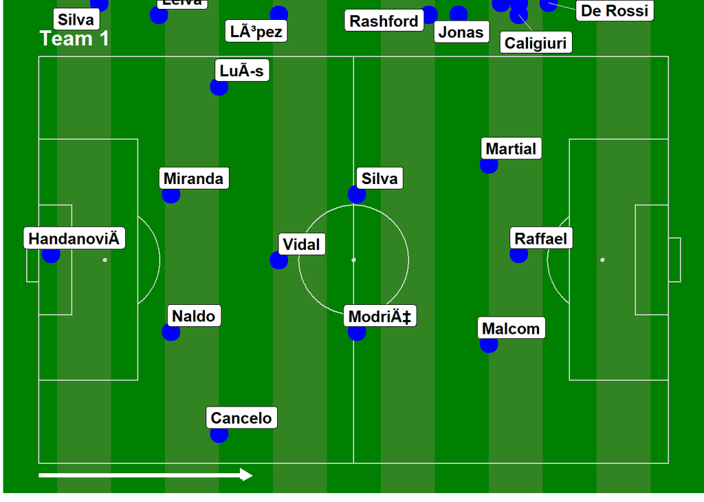

#### Team 2

For the second team we use the exact same procedure as the first team, we just change the upper limit of the value constrain to 700 million euros.

```
##        ID                  Name Overall Potential    Value Position fair_value
## 1   20801     Cristiano Ronaldo      94        94 77000000       ST  131200141
## 2  177003            L. ModriÄ‡      91        91 67000000      RCM   84916451
## 3  168542           David Silva      90        90 60000000      LCM   72280019
## 4  182493             D. GodÃn      90        90 44000000       CB   57220939
## 5  138956          G. Chiellini      89        89 27000000      LCB   50360773
## 6  167495              M. Neuer      89        89 38000000       GK   42905473
## 7  215914             N. KantÃ©      89        90 63000000      LDM   63286180
## 8  164240          Thiago Silva      88        88 24000000      RCB   39999458
## 9  176676               Marcelo      88        88 43000000       LB   45497109
## 10     41               Iniesta      86        86 21500000       LF   36140076
## 11 135507           Fernandinho      86        86 18000000      CDM   32848921
## 12 218667        Bernardo Silva      86        91 59500000       RW   59777470
## 13 181872              A. Vidal      85        85 26000000      CAM   33551102
## 14 211300            A. Martial      84        90 42500000       LW   45948280
## 15  53302           D. De Rossi      83        83  8000000      RDM   20690862
## 16 210514         JoÃ£o Cancelo      82        88 25500000       RB   26136317
## 17 144622               Raffael      81        81 11000000       CF   15586577
## 18 180216            S. Coleman      80        80 11000000      RWB   11213749
## 19 198784 A. Oxlade-Chamberlain      80        85 19500000       CM   19746732
## 20 200536             N. Schulz      80        81 14500000      LWB   13687706
```

```
## [1] 20
```

```
## [1] 7e+08
```

```
## [1] 86.05
```

To meet the team requirements, the team should have 2 GK, 2 CB and 2 LW players. To make this adjustment we make a swap with players in LCB, LF and CDM positions for the required players of the same value.

```r
#remove the 3 players
team2<-filter(team2,!(team2$Position %in% c('LCB','LF','CDM')))
#store replacement players in a variable
rep<-select(filter(players,players$ID %in% c(231677,221087,168609)),c('ID','Name','Overall','Potential','Value','Position'))
#add replacement players to the team
team2<-rbind(select(team2,-c('fair_value')),rep)

#new team2
team2
```

```
##        ID                  Name Overall Potential    Value Position
## 1   20801     Cristiano Ronaldo      94        94 77000000       ST
## 2  177003            L. ModriÄ‡      91        91 67000000      RCM
## 3  168542           David Silva      90        90 60000000      LCM
## 4  182493             D. GodÃn      90        90 44000000       CB
## 5  167495              M. Neuer      89        89 38000000       GK
## 6  215914             N. KantÃ©      89        90 63000000      LDM
## 7  164240          Thiago Silva      88        88 24000000      RCB
## 8  176676               Marcelo      88        88 43000000       LB
## 9  218667        Bernardo Silva      86        91 59500000       RW
## 10 181872              A. Vidal      85        85 26000000      CAM
## 11 211300            A. Martial      84        90 42500000       LW
## 12  53302           D. De Rossi      83        83  8000000      RDM
## 13 210514         JoÃ£o Cancelo      82        88 25500000       RB
## 14 144622               Raffael      81        81 11000000       CF
## 15 180216            S. Coleman      80        80 11000000      RWB
## 16 198784 A. Oxlade-Chamberlain      80        85 19500000       CM
## 17 200536             N. Schulz      80        81 14500000      LWB
## 18 168609               Miranda      85        85 15500000       CB
## 19 221087            Pau LÃ³pez      82        87 21500000       GK
## 20 231677           M. Rashford      81        89 27000000       LW
```

```r
#check if there are 20 players
nrow(team2)
```

```
## [1] 20
```

```r
#check the new total value of the team
sum(team2$Value)
```

```
## [1] 697500000
```

```r
#check the new team overall rating
sum(team2$Overall)/20
```

```
## [1] 85.4
```

```r
#Number of players that are common in both teams
sum(team2$Name %in% team1$Name)
```

```
## [1] 13
```

**Imapact of adjustment**

From the results of the adjusted team above, it can be noted that this adjustment a minor impact of the value of the total team as it has slighly decreased but it is still within the budget constraint. This adjustment has also slightly decreased the overall rating of the team from 86.05% to 85.4%.

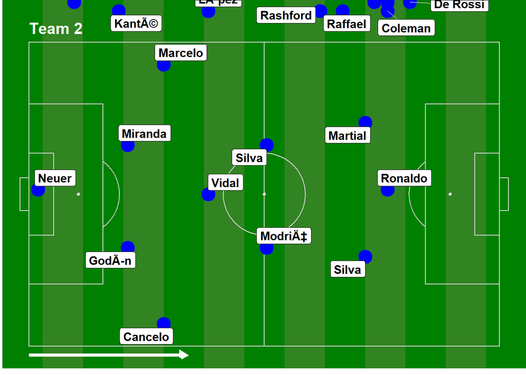

#### Team 3

For the third team we dont just use undervalued players but we use all the players in the data set to select the 20 best players without any budget constraints and we do this using linear programming as well.

```r
#required positions for the team
sel_positions<-c('GK','RCB','LB','RB','CB','LCB','CDM','LWB','RWB','CAM','CM','LDM','RDM','LCM','RCM','ST','CF','LW','RW','RF','RW')
players<-arrange(filter(data,data$Position %in% sel_positions),desc(-ID))
molten_data<-melt(players,id.vars = c('ID','Name'),value.name = 'Position',measure.vars = 'Position')
constraint_matrix<-acast(molten_data,Position ~ ID,fun.aggregate = length,value.var = 'Name' )
npos<-nrow(constraint_matrix)
constraint_dir3<-rep("==",npos)
constraint_limit3<-rep(1,npos)
lp_solution3<-lp(direction = 'max',players$Overall,constraint_matrix,constraint_dir3,constraint_limit3,all.int = T,transpose.constraints = T)

#The selected team
team3<-players%>%
  select(c('Name','Overall','Potential','Position','Value'))%>%
  filter(lp_solution3$solution==1)%>%
  arrange(desc(Overall))

team3
```

```
##                 Name Overall Potential Position     Value
## 1  Cristiano Ronaldo      94        94       ST  77000000
## 2           L. Messi      94        94       RF 110500000
## 3          Neymar Jr      92        93       LW 118500000
## 4       Sergio Ramos      91        91      RCB  51000000
## 5         L. ModriÄ‡      91        91      RCM  67000000
## 6             De Gea      91        93       GK  72000000
## 7        David Silva      90        90      LCM  60000000
## 8          D. GodÃn      90        90       CB  44000000
## 9       G. Chiellini      89        89      LCB  27000000
## 10   Sergio Busquets      89        89      CDM  51500000
## 11      A. Griezmann      89        90      CAM  78000000
## 12         N. KantÃ©      89        90      LDM  63000000
## 13           Marcelo      88        88       LB  43000000
## 14          P. Pogba      87        91      RDM  64000000
## 15       Azpilicueta      86        86       RB  35000000
## 16            Thiago      86        86       CM  45500000
## 17       R. Sterling      86        89       RW  56500000
## 18       S. Giovinco      82        82       CF  20000000
## 19        S. Coleman      80        80      RWB  11000000
## 20         N. Schulz      80        81      LWB  14500000
```

```r
#check if there are no duplicate positions
length(unique(team3$Position))
```

```
## [1] 20
```

```r
#Total value for team 3
sum(team3$Value)
```

```
## [1] 1.109e+09
```

```r
#Team Overall rating for team 3
lp_solution3$objval/20
```

```
## [1] 88.2
```

```r
#number of undervalued players in team 3
sum(team3$Name %in% undervalue_players$Name)
```

```
## [1] 11
```

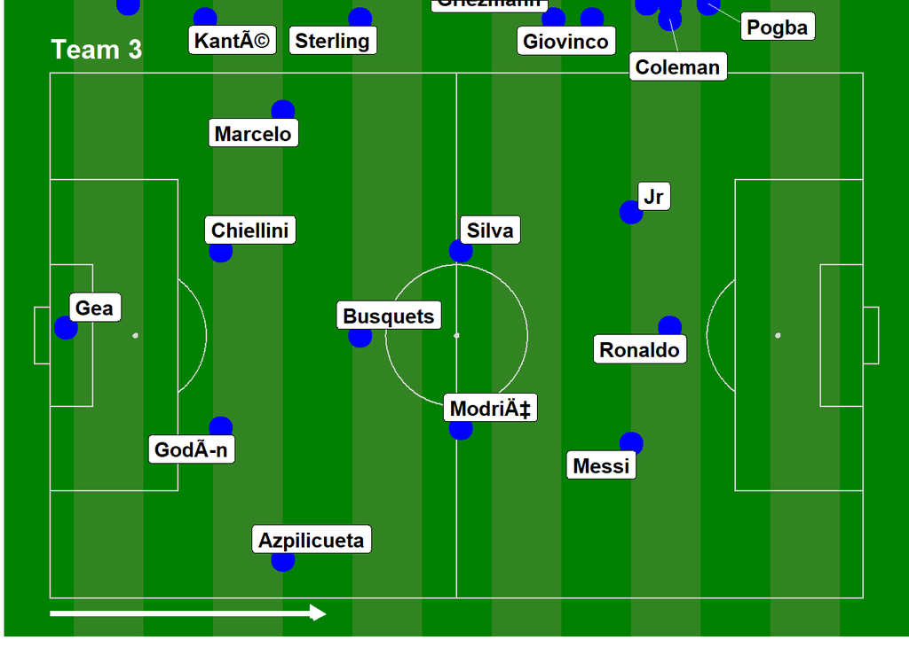

#### Conclusion

From the results of this project, it can also be noted how powerful statistics driven approach is in player valuation as we were able to use regression models to identify undervalued players and r linear programming technique to construct teams for given constraints.

In this section we give a brief comparison on the three constructed teams. When comparing the two constrained teams, the most obvious difference is that the extra 200 millions budget in team 2 was able to improve the team rating from 84.55% to 86.05% and this meant that only 7 players had to change as 13 players didn’t change. In team2 there exist some highly rated players such as Ronaldo but the overall player rating doesn’t vary that much in both teams is about the same.